# Attente au SU

```r
date()
```

```
## [1] "Mon Mar 17 18:49:16 2014"
```

## Variables globales:

Charge le fichier source **d1**

```r
source("../prologue.R")
```

[output not shown]

```
## [1] "Fichier courant: rpu2013d0112.Rda"
```

```r
wd
```

```
## [1] "/home/jcb/Documents/Resural/Stat Resural/RPU_2013/Analyse/Chapitres/Attente SU"
```

```r
N <- nrow(d1)
N
```

```
## [1] 340338
```

## Librairies nécessaires:

```r
load_libraries()
```

```
## Error: impossible de trouver la fonction "load_libraries"
```

## Heure d'arrivée aux urgences

Inspiré du rapport activité de l'OruLim

```r
e <- ymd_hms(d1$ENTREE)
h <- hour(e)
sh <- table(as.factor(h))
sh
```

```
##
##     0     1     2     3     4     5     6     7     8     9    10    11
##  7001  5650  4529  3898  3394  3238  3584  6105 13676 19662 22533 21483
##    12    13    14    15    16    17    18    19    20    21    22    23
## 18378 19427 22159 21289 20911 21802 21830 20314 19822 16640 13596  9417
```

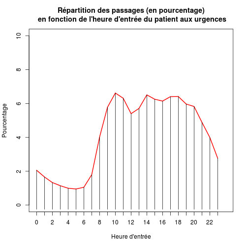

```r
psh <- plot(prop.table(sh) * 100, type = "l", col = "red", xlim = c(0, 24),
    ylab = "Pourcentage", xlab = "Heure d'entrée", main = "Répartition des passages (en pourcentage)\n en fonction de l'heure d'entrée du patient aux urgences",
    ylim = c(0, 10))
prsh <- prop.table(sh) * 100
for (i in 1:24) {
    segments(psh[i], -0.25, psh[i], prsh[i])
}
```

```r
# Sorties
s <- ymd_hms(d1$SORTIE)
h <- hour(s)
sh <- table(as.factor(h))
sh
```

```
##
##     0     1     2     3     4     5     6     7     8     9    10    11
## 10341  7877  5994  4504  3339  2754  2269  6081  5853  9785 14313 17087
##    12    13    14    15    16    17    18    19    20    21    22    23
## 17524 15545 17281 22452 19853 20181 20473 18974 18006 16947 17000 15564
```

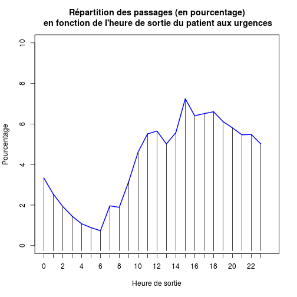

```r
psh <- plot(prop.table(sh) * 100, type = "l", col = "blue", xlim = c(0, 24),
    ylab = "Pourcentage", xlab = "Heure de sortie", main = "Répartition des passages (en pourcentage)\n en fonction de l'heure de sortie du patient aux urgences",
    ylim = c(0, 10))
prsh <- prop.table(sh) * 100
for (i in 1:24) {
    segments(psh[i], -0.25, psh[i], prsh[i])
}
```

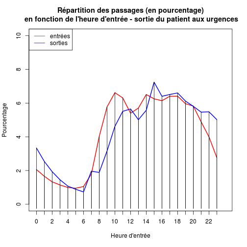

```r
# Entées et sorties
h <- hour(e)
sh <- table(as.factor(h))
psh <- plot(prop.table(sh) * 100, type = "l", col = "red", xlim = c(0, 24),
    ylab = "Pourcentage", xlab = "Heure d'entrée", main = "Répartition des passages (en pourcentage)\n en fonction de l'heure d'entrée - sortie du patient aux urgences",
    ylim = c(0, 10))
prsh <- prop.table(sh) * 100
for (i in 1:24) {
    segments(psh[i], -0.25, psh[i], prsh[i])
}

h <- hour(s)
sh <- table(as.factor(h))
lines(prop.table(sh) * 100, type = "l", col = "blue", xlim = c(0, 24), , ylim = c(0,
    10))
prsh <- prop.table(sh) * 100
for (i in 1:24) {
    segments(psh[i], -0.25, psh[i], prsh[i])
}

legend("topleft", legend = c("entrées", "sorties"), col = c("red", "blue"),
    lty = 1)
```

## Diurne - Nocturne

- diurne: 8h - 19h59
- nocturne: 20h - 7h59

```r
h <- hour(e)
t <- table(h)  # t[1] correspond à t0
e_nocturne <- sum(t[1:8]) + sum(t[21:24])
e_diurne <- sum(t[9:20])
n <- e_diurne + e_nocturne
admission_diurne <- round(e_diurne * 100/n, 2)

h <- hour(s)
t <- table(h)  # t[1] correspond à t0
s_nocturne <- sum(t[1:8]) + sum(t[21:24])
s_diurne <- sum(t[9:20])
n <- s_diurne + s_nocturne
sortie_diurne <- round(s_diurne * 100/n, 2)
```

admission diurne: 71.54 %

**Recours nocturne: 28.46 %**

sortie diurne: 64.3 %

ratio entrée/sortie diurne: 1.22

ratio entrée/sortie nocturne: 0.88

## Entrée - sorties pédiatriques

NOTE: faire une fonction gébérique

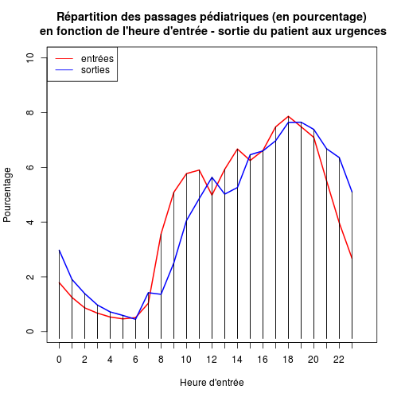

```r
e <- ymd_hms(d1$ENTREE[d1$AGE < 18])
h <- hour(e)
sh <- table(as.factor(h))
psh <- plot(prop.table(sh) * 100, type = "l", col = "red", xlim = c(0, 24),
    ylab = "Pourcentage", xlab = "Heure d'entrée", main = "Répartition des passages pédiatriques (en pourcentage)\n en fonction de l'heure d'entrée - sortie du patient aux urgences",
    ylim = c(0, 10))
prsh <- prop.table(sh) * 100
for (i in 1:24) {
    segments(psh[i], -0.25, psh[i], prsh[i])
}

s <- ymd_hms(d1$SORTIE[d1$AGE < 18])
h <- hour(s)
sh <- table(as.factor(h))
lines(prop.table(sh) * 100, type = "l", col = "blue", xlim = c(0, 24), , ylim = c(0,
    10))
prsh <- prop.table(sh) * 100
for (i in 1:24) {
    segments(psh[i], -0.25, psh[i], prsh[i])
}

legend("topleft", legend = c("entrées", "sorties"), col = c("red", "blue"),
    lty = 1)
```

## Entrée - sorties adultes

NOTE: faire une fonction gébérique

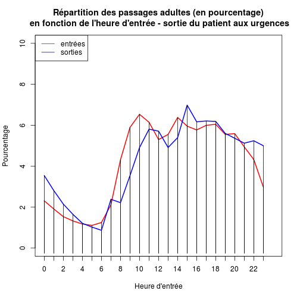

```r
e <- ymd_hms(d1$ENTREE[d1$AGE >= 18 & d1$AGE < 75])
h <- hour(e)
sh <- table(as.factor(h))
psh <- plot(prop.table(sh) * 100, type = "l", col = "red", xlim = c(0, 24),
    ylab = "Pourcentage", xlab = "Heure d'entrée", main = "Répartition des passages adultes (en pourcentage)\n en fonction de l'heure d'entrée - sortie du patient aux urgences",
    ylim = c(0, 10))
prsh <- prop.table(sh) * 100
for (i in 1:24) {
    segments(psh[i], -0.25, psh[i], prsh[i])
}

s <- ymd_hms(d1$SORTIE[d1$AGE >= 18 & d1$AGE < 75])
h <- hour(s)
sh <- table(as.factor(h))
lines(prop.table(sh) * 100, type = "l", col = "blue", xlim = c(0, 24), , ylim = c(0,
    10))
prsh <- prop.table(sh) * 100
for (i in 1:24) {
    segments(psh[i], -0.25, psh[i], prsh[i])
}

legend("topleft", legend = c("entrées", "sorties"), col = c("red", "blue"),
    lty = 1)
```

## Entrée - sorties gériatriques

NOTE: faire une fonction générique

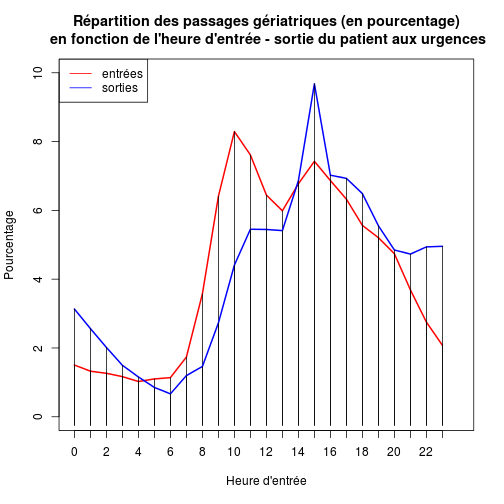

```r
e <- ymd_hms(d1$ENTREE[d1$AGE > 74])
h <- hour(e)
sh <- table(as.factor(h))
psh <- plot(prop.table(sh) * 100, type = "l", col = "red", xlim = c(0, 24),
    ylab = "Pourcentage", xlab = "Heure d'entrée", main = "Répartition des passages gériatriques (en pourcentage)\n en fonction de l'heure d'entrée - sortie du patient aux urgences",
    ylim = c(0, 10))
prsh <- prop.table(sh) * 100
for (i in 1:24) {
    segments(psh[i], -0.25, psh[i], prsh[i])
}

s <- ymd_hms(d1$SORTIE[d1$AGE > 74])
h <- hour(s)
sh <- table(as.factor(h))
lines(prop.table(sh) * 100, type = "l", col = "blue", xlim = c(0, 24), , ylim = c(0,
    10))
prsh <- prop.table(sh) * 100
for (i in 1:24) {
    segments(psh[i], -0.25, psh[i], prsh[i])
}

legend("topleft", legend = c("entrées", "sorties"), col = c("red", "blue"),
    lty = 1)
```

## Semaine - Week-end

- semaine: du lundi 8h au vendredi 19h59
- week-end: du vendredi 20h au lundi 7h59

```r
e_dom
```

```
## Error: objet 'e_dom' introuvable
```

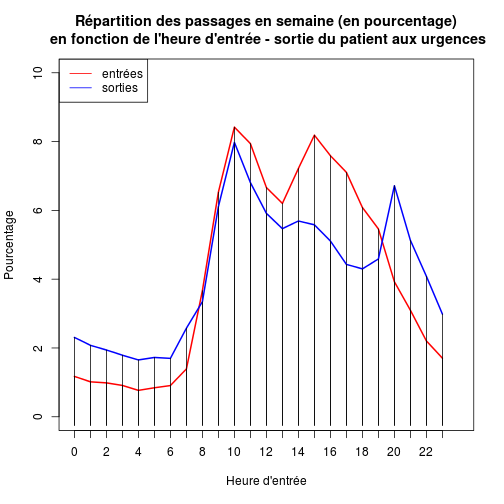

```r
# admissions
semaine <- e[wday(e) %in% c(3:5) | (wday(e) == 2 & hour(e) > 7) | (wday(e) ==
    6 & hour(e) < 20)]
weekend <- e[wday(e) %in% c(7, 1) | (wday(e) == 6 & hour(e) > 19) | (wday(e) ==
    2 & hour(e) < 8)]
n_se <- length(semaine)
n_we <- length(weekend)

# sorties
s_semaine <- s[wday(s) %in% c(3:5) | (wday(s) == 2 & hour(s) > 7) | (wday(s) ==
    6 & hour(s) < 20)]
s_weekend <- s[wday(s) %in% c(7, 1) | (wday(s) == 6 & hour(s) > 19) | (wday(s) ==
    2 & hour(s) < 8)]
n_sse <- length(s_semaine)
n_swe <- length(s_weekend)

# graphe entrées semaine/we

h <- hour(semaine)
sh <- table(as.factor(h))
psh <- plot(prop.table(sh) * 100, type = "l", col = "red", xlim = c(0, 24),
    ylab = "Pourcentage", xlab = "Heure d'entrée", main = "Répartition des passages en semaine (en pourcentage)\n en fonction de l'heure d'entrée - sortie du patient aux urgences",
    ylim = c(0, 10))
prsh <- prop.table(sh) * 100
for (i in 1:24) {
    segments(psh[i], -0.25, psh[i], prsh[i])
}

h <- hour(weekend)
sh <- table(as.factor(h))
lines(prop.table(sh) * 100, type = "l", col = "blue", xlim = c(0, 24), , ylim = c(0,
    10))
prsh <- prop.table(sh) * 100
for (i in 1:24) {
    segments(psh[i], -0.25, psh[i], prsh[i])
}

legend("topleft", legend = c("entrées", "sorties"), col = c("red", "blue"),
    lty = 1)
```

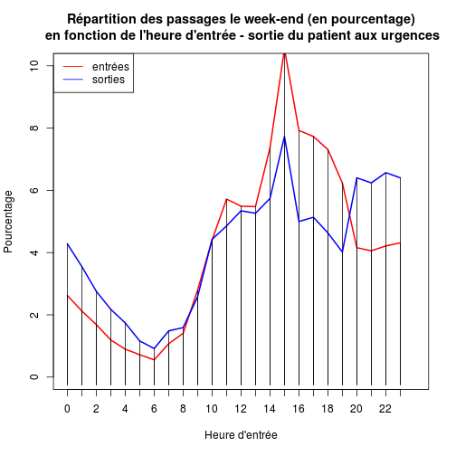

```r
# graphue des sorties semaine/we

h <- hour(s_semaine)
sh <- table(as.factor(h))
psh <- plot(prop.table(sh) * 100, type = "l", col = "red", xlim = c(0, 24),
    ylab = "Pourcentage", xlab = "Heure d'entrée", main = "Répartition des passages le week-end (en pourcentage)\n en fonction de l'heure d'entrée - sortie du patient aux urgences",
    ylim = c(0, 10))
prsh <- prop.table(sh) * 100
for (i in 1:24) {
    segments(psh[i], -0.25, psh[i], prsh[i])
}

h <- hour(s_weekend)
sh <- table(as.factor(h))
lines(prop.table(sh) * 100, type = "l", col = "blue", xlim = c(0, 24), , ylim = c(0,
    10))
prsh <- prop.table(sh) * 100
for (i in 1:24) {
    segments(psh[i], -0.25, psh[i], prsh[i])
}

legend("topleft", legend = c("entrées", "sorties"), col = c("red", "blue"),
    lty = 1)
```

[output not shown]

- sorties en semaine 38550
- sorties le weekend: 21117
- pourcentage de sorties en semaine: 64.61

## Entrées sorties des hospitalisés

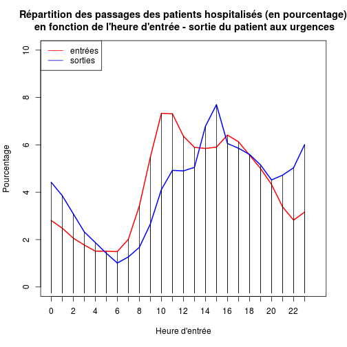

```r
e_hosp <- d1$ENTREE[d1$MODE_SORTIE %in% c("Mutation", "Transfert")]
s_hosp <- d1$SORTIE[d1$MODE_SORTIE %in% c("Mutation", "Transfert")]

h <- hour(e_hosp)
sh <- table(as.factor(h))
psh <- plot(prop.table(sh) * 100, type = "l", col = "red", xlim = c(0, 24),
    ylab = "Pourcentage", xlab = "Heure d'entrée", main = "Répartition des passages des patients hospitalisés (en pourcentage)\n en fonction de l'heure d'entrée - sortie du patient aux urgences",
    ylim = c(0, 10))
prsh <- prop.table(sh) * 100
for (i in 1:24) {
    segments(psh[i], -0.25, psh[i], prsh[i])
}

h <- hour(s_hosp)
sh <- table(as.factor(h))
lines(prop.table(sh) * 100, type = "l", col = "blue", xlim = c(0, 24), , ylim = c(0,
    10))
prsh <- prop.table(sh) * 100
for (i in 1:24) {
    segments(psh[i], -0.25, psh[i], prsh[i])
}

legend("topleft", legend = c("entrées", "sorties"), col = c("red", "blue"),
    lty = 1)
```

## Entrées sorties des retours à domicile

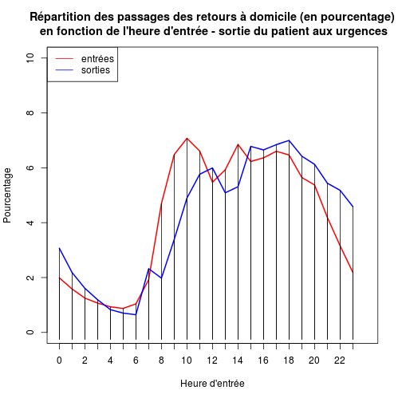

```r
e_dom <- d1$ENTREE[d1$MODE_SORTIE %in% c("Domicile")]
s_dom <- d1$SORTIE[d1$MODE_SORTIE %in% c("Domicile")]

h <- hour(e_dom)
sh <- table(as.factor(h))
psh <- plot(prop.table(sh) * 100, type = "l", col = "red", xlim = c(0, 24),
    ylab = "Pourcentage", xlab = "Heure d'entrée", main = "Répartition des passages des retours à domicile (en pourcentage)\n en fonction de l'heure d'entrée - sortie du patient aux urgences",
    ylim = c(0, 10))
prsh <- prop.table(sh) * 100
for (i in 1:24) {
    segments(psh[i], -0.25, psh[i], prsh[i])
}

h <- hour(s_dom)
sh <- table(as.factor(h))
lines(prop.table(sh) * 100, type = "l", col = "blue", xlim = c(0, 24), , ylim = c(0,
    10))
prsh <- prop.table(sh) * 100
for (i in 1:24) {
    segments(psh[i], -0.25, psh[i], prsh[i])
}

legend("topleft", legend = c("entrées", "sorties"), col = c("red", "blue"),
    lty = 1)
```

## CHU

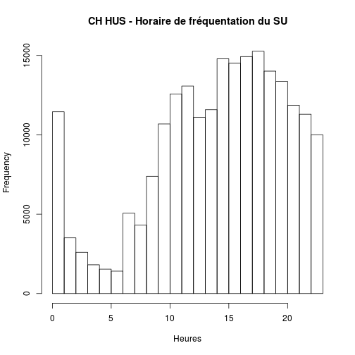

```r
hist(h, breaks = 23, xlab = "Heures", main = "CH HUS - Horaire de fréquentation du SU")
```

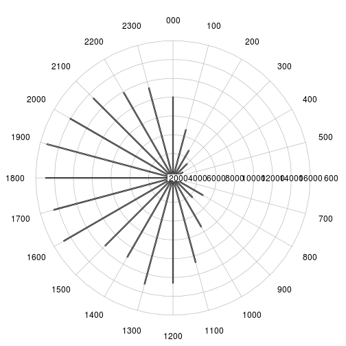

```r
t <- table(h)
t2 <- as.integer(t)
c <- clock24.plot(t2, clock.pos = 1:24, lwd = 3)
```

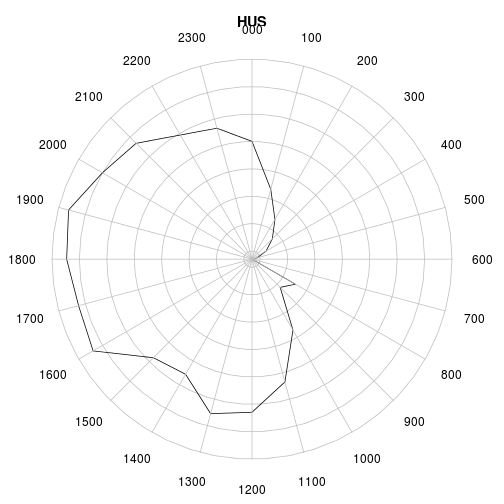

```r
c <- clock24.plot(t2, clock.pos = 1:24, rp.type = "p", main = "HUS", xlab = "Heures d'arrivée aux urgences",
    show.grid.labels = F)
```

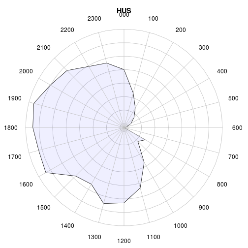

```r
# nécessite la librairie openintro
clock24.plot(t2, clock.pos = 1:24, rp.type = "p", main = "HUS", xlab = "Heures d'arrivée aux urgences",
    show.grid.labels = F, poly.col = fadeColor("blue", fade = "10"))
```

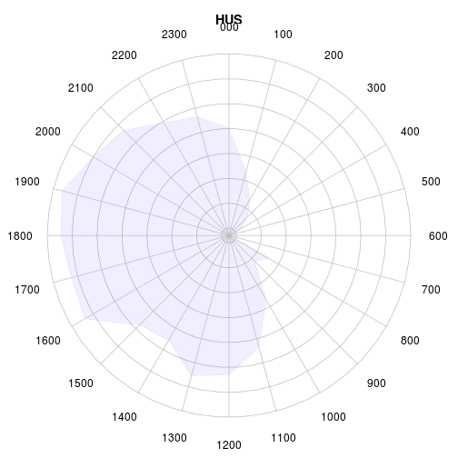

```r
clock24.plot(t2, clock.pos = 1:24, rp.type = "p", main = "HUS", xlab = "Heures d'arrivée aux urgences",
    show.grid.labels = F, poly.col = fadeColor("blue", fade = "10"), line.col = fadeColor("blue",
        fade = "10"))
```

Idem pour les sorties

```r
s <- ymd_hms(geb$SORTIE)
```

```
## Error: objet 'geb' introuvable
```

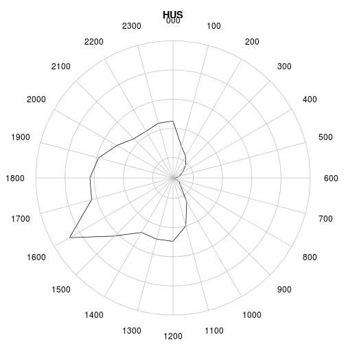

```r
t3 <- as.integer(table(hour(s)))
clock24.plot(t3, clock.pos = 1:24, rp.type = "p", main = "HUS", xlab = "Heures de sortie des urgences",
    show.grid.labels = F)
```

## Durée de présence

La durée de présence est calculée en secondes. Il faut la diviser par 60 pour avoir des minutes:

```r
e <- ymd_hms(d1$ENTREE)
s <- ymd_hms(d1$SORTIE)
d1$presence <- s - e
d1$presence <- (s - e)/60
summary(as.numeric(d1$presence))
```

```
##    Min. 1st Qu.  Median    Mean 3rd Qu.    Max.    NA's
##    -247      55     110     163     204    9870   30341
```

```r
# suppression des valeurs négatives
d1$presence[d1$presence < 0] <- NA
# suppression des valeurs supérieures à 4 jours (5760 minutes)
d1$presence[d1$presence > 5760] <- NA
d1$presence <- as.numeric(d1$presence)
sdp <- summary(d1$presence)
sdp
```

```
##    Min. 1st Qu.  Median    Mean 3rd Qu.    Max.    NA's
##       0      55     110     163     204    5710   30347
```

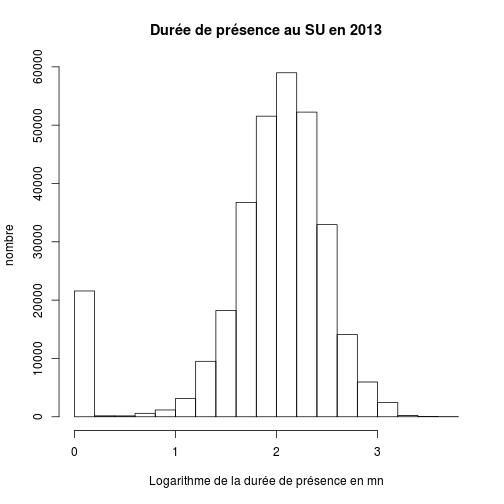

```r
hist(log10(as.numeric(d1$presence)), ylab = "nombre", xlab = "Logarithme de la durée de présence en mn",
    main = "Durée de présence au SU en 2013")
```

```r
# la transformation log produit une courbe normale où lamajorité des
# consultants ont une durée de présence comprise entre 10 et 1000 minutes
# (environ 17 heures). On nettoie les données en supprimant les
# enregistrements où presence = NA, puis on forme 3 sous-groupes: - a moins
# de 10 mn - b de 10 à 1000 mn - c plus de 1000 mn
d2 <- d1[!is.na(d1$presence), ]
a <- d2$presence[d2$presence < 10]
c <- d2$presence[d2$presence > 1000]
b <- d2$presence[d2$presence > 9 & d2$presence < 1001]
length(a)
```

```
## [1] 23397
```

```r
length(b)
```

```
## [1] 283871
```

```r
length(c)
```

```
## [1] 2723
```

```r
summary(b)
```

```
##    Min. 1st Qu.  Median    Mean 3rd Qu.    Max.
##      10      65     120     164     211    1000
```

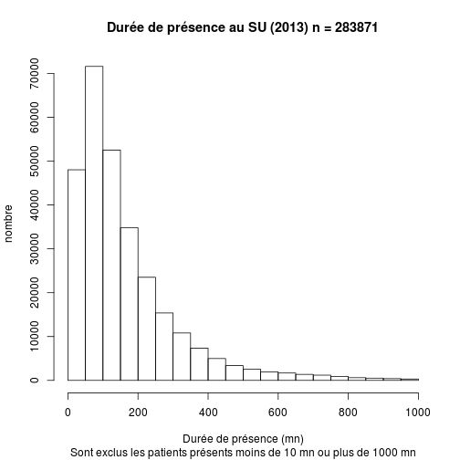

```r
hist(b, ylab = "nombre", xlab = "Durée de présence (mn)", main = paste("Durée de présence au SU (2013) n =",
    length(b)), sub = "Sont exclus les patients présents moins de 10 mn ou plus de 1000 mn")
```

```r
# Origine despatients restants moins de 10 mn: ils proviennent
# majoritairement des HUS:
a <- d2[d2$presence < 10, "FINESS"]
rbind(table(a), round(prop.table(table(a)) * 100, 2))
```

```
##         3Fr   Alk    Col    Dia    Geb    Hag      Hus    Mul    Odi   Sel
## [1,] 179.00 64.00 283.00 246.00 108.00 165.00 21430.00 442.00 108.00 42.00
## [2,]   0.77  0.27   1.21   1.05   0.46   0.71    91.59   1.89   0.46  0.18
##         Wis    Sav
## [1,] 151.00 179.00
## [2,]   0.65   0.77
```

```r
# Plus de 90% proviennent des HUS
```

**Durée moyenne de présence: 163 mn**  
**Durée médiane de présence: 110 mn**

## Moyenne des durées de passages par jour

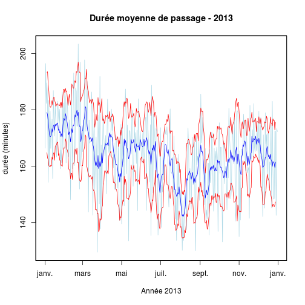

```r
# On ne garde que les passages > 10 mn et < 1000 mn
b <- d2[d2$presence > 9 & d2$presence < 1001, c("ENTREE", "presence")]
# on calcule la moyenne des passages par jour
c <- tapply(b$presence, as.Date(b$ENTREE), mean)
# on fabrique un vecteur de date
d <- unique(as.Date(b$ENTREE))
a <- zoo(c, d)
plot(a, ylab = "durée (minutes)", main = "Durée moyenne de passage - 2013",
    xlab = "Année 2013", col = "lightblue")
lines(rollmean(a, 7), col = "blue")
lines(rollapply(a, 7, function(x) mean(x) + sd(x)), col = "red")
lines(rollapply(a, 7, function(x) mean(x) - sd(x)), col = "red")
```

Combinaison entrée-sortie

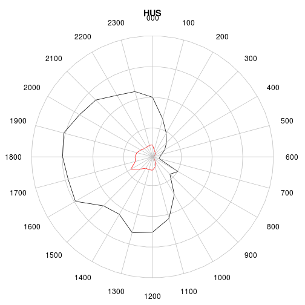

```r
t4 <- rbind(t2, t3)
clock24.plot(t4, clock.pos = 1:24, rp.type = "p", main = "HUS", xlab = "Heures d'arrivée aux urgences",
    show.grid.labels = F)
```

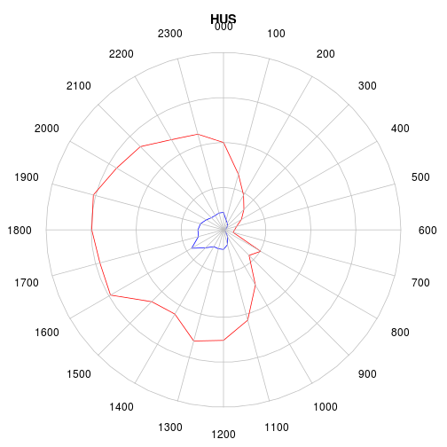

```r
clock24.plot(t4, clock.pos = 1:24, rp.type = "p", main = "HUS", xlab = "Heures d'arrivée aux urgences",
    show.grid.labels = F, line.col = c("red", "blue"))
```

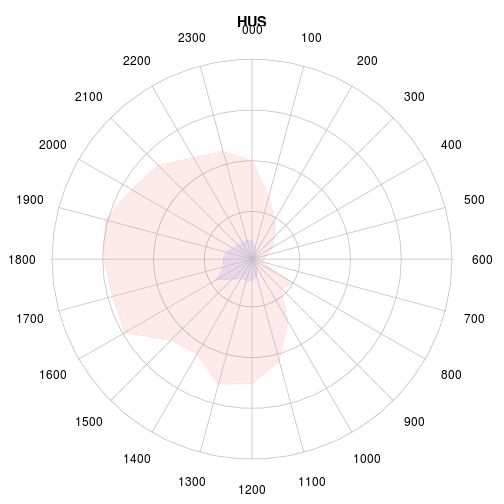

```r
fadeBlue <- fadeColor("blue", fade = "15")
fadeRed <- fadeColor("red", fade = "15")
clock24.plot(t4, clock.pos = 1:24, rp.type = "p", main = "HUS", xlab = "Heures d'arrivée aux urgences",
    show.grid.labels = F, line.col = c(fadeRed, fadeBlue), poly.col = c(fadeRed,
        fadeBlue))
```

```r
e <- ymd_hms(geb$ENTREE)
```

```
## Error: objet 'geb' introuvable
```

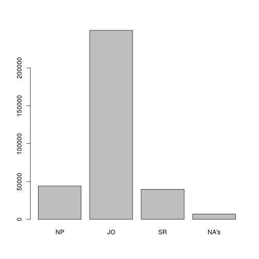

```r
h <- hour(e)
b <- cut(h, c(0, 8, 20, 24), labels = c("NP", "JO", "SR"))
bp <- summary(as.factor(b))
barplot(bp)
```

```r
round(prop.table(bp) * 100, 2)
```

```
##    NP    JO    SR  NA's
## 12.95 73.34 11.65  2.06
```

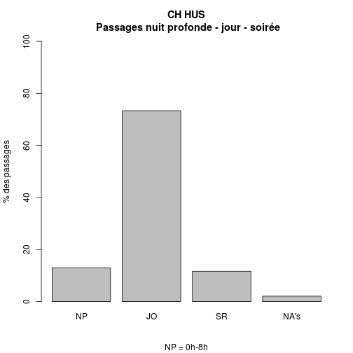

```r
barplot(round(prop.table(bp) * 100, 2), ylab = "% des passages", sub = "NP = 0h-8h",
    ylim = c(0, 100), main = "CH HUS\n Passages nuit profonde - jour - soirée")
```

```r
t <- table(geb$GRAVITE, b)
```

```
## Error: objet 'geb' introuvable
```

```r
t
```

```
## h
##     0     1     2     3     4     5     6     7     8     9    10    11
##  6695  4757  3508  2597  1812  1538  1410  5068  4316  7386 10685 12576
##    12    13    14    15    16    17    18    19    20    21    22    23
## 13076 11103 11582 14792 14508 14930 15264 14011 13365 11866 11298 10004
```

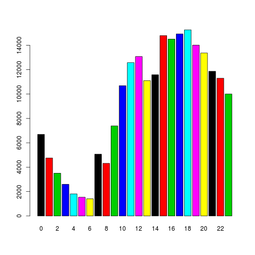

```r
barplot(t, beside = T, col = 1:7)
```

Mode sortie en fonction de la période

```r
t <- table(geb$MODE_SORTIE, b)
```

```
## Error: objet 'geb' introuvable
```

```r
t
```

```
## h
##     0     1     2     3     4     5     6     7     8     9    10    11
##  6695  4757  3508  2597  1812  1538  1410  5068  4316  7386 10685 12576
##    12    13    14    15    16    17    18    19    20    21    22    23
## 13076 11103 11582 14792 14508 14930 15264 14011 13365 11866 11298 10004
```

```r
t <- table(geb$ORIENTATION, b)
```

```
## Error: objet 'geb' introuvable
```